# A quick guide to the *gDefrag* package

Frederico Mestre, Fernando Ascensao & A. Marcia Barbosa

May 24, 2018

The *gDefrag* package provides a set of tools to assist the de-fragmentation of landscapes. It works by prioritizing the different sections of linear infrastructures (e.g. roads, railways) to increase the available amount of a given resource for a particular species or group.

First you need to (install and) load the *gDefrag* package:

```r
if (!require(gDefrag)) devtools::install_github("FMestre1/gDefrag")
library(gDefrag)
```

Now load and take a look at the example dataset that comes with the package, which is a vector map of polygons separated by major roads:

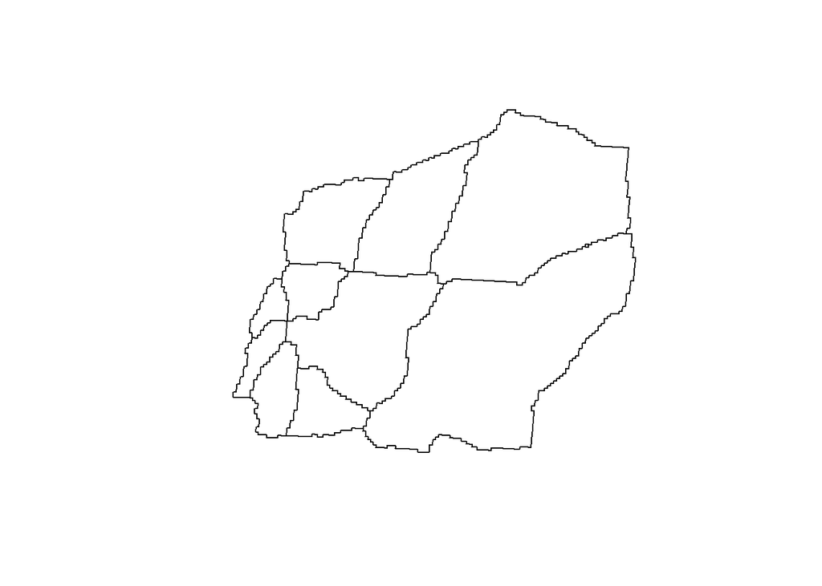

```r
data(road_P)
plot(road_P)
```

You can also look at the attribute table associated to these polygons. You can see that there are several variables, including the area and forest cover within each polygon:

```r
road_P@data
```

```
##      X  X.. X.... forest_sum       pArea forest_amount   proportion
## 0    7 0.20  2.41    4868363  1912049316         74344 3.888184e-05
## 1    8 1.81  7.79   30852092 17112435259        485876 2.839315e-05
## 2  110 0.07  1.44     965843   648016387         14479 2.234357e-05
## 3  164 0.00  0.08      10350     4000099           201 5.024875e-05
## 4   12 0.10  1.92    1962820   924023592         30344 3.283899e-05
## 5  114 0.16  1.95    5605925  1500037762         86649 5.776455e-05
## 6   15 0.73  4.64   14358291  6916175648        207109 2.994560e-05
## 7  117 0.37  3.08    9608527  3468086108        140760 4.058723e-05
## 8  118 1.34  5.82   15564745 12540309203        194907 1.554244e-05
## 9   33 0.19  2.22    3493142  1764045377         52951 3.001680e-05
## 10 119 0.53  3.86    5968472  4968123064         81033 1.631059e-05
```

You can start by using the `node.creation` function to create a spatial object containing the potential nodes (one in each polygon) and their attributes, based on a given column (in this case, we will choose “forest_sum”) of the polygons map:

```r
out1 <- node.creation(land_polyg = road_P, value_col = "forest_sum", scale_nodes = 10)
```

[figure not shown]

```r
out2 <- edge.creation (nodes = out1, land_polyg = road_P, min_length = 10000, min_pol_area = 1000000)
```

[figure not shown]

Now you can calculate priorities for those edges according to a given criterion, which can currently be either `"value"`, `"between"`, `"IIC"` or `"AWM"` (see `help(prioritize)` for details). Let’s try it with the first one and look at the results:

```r
out3 <- prioritize(nodes = out1, edges = out2, method = "value")
head(out3@data)
```

```
##   node_A node_B    distance  x_node_A y_node_A  x_node_B y_node_B  value_A
## 1      1      2 16539189287 -755319.2  4412758 -623267.1  4457644  4868363
## 3      3      5   299973724 -794192.9  4483820 -805995.3  4445037   965843
## 4      3      6   930606946 -794192.9  4483820 -765834.3  4497663   965843
## 5      1      7  5458404969 -755319.2  4412758 -738490.8  4459211  4868363
## 6      2      7 11080784433 -623267.1  4457644 -738490.8  4459211 30852092
## 7      5      7  6531425119 -805995.3  4445037 -738490.8  4459211  1962820
##    value_B road_length priorization
## 1 30852092    18397.89     86.66667
## 3  1962820    40139.65      0.00000
## 4  5605925    38696.10     13.33333
## 5 14358291    92703.10     53.33333
## 6 14358291   152518.75     93.33333
## 7 14358291    16086.73     40.00000
```

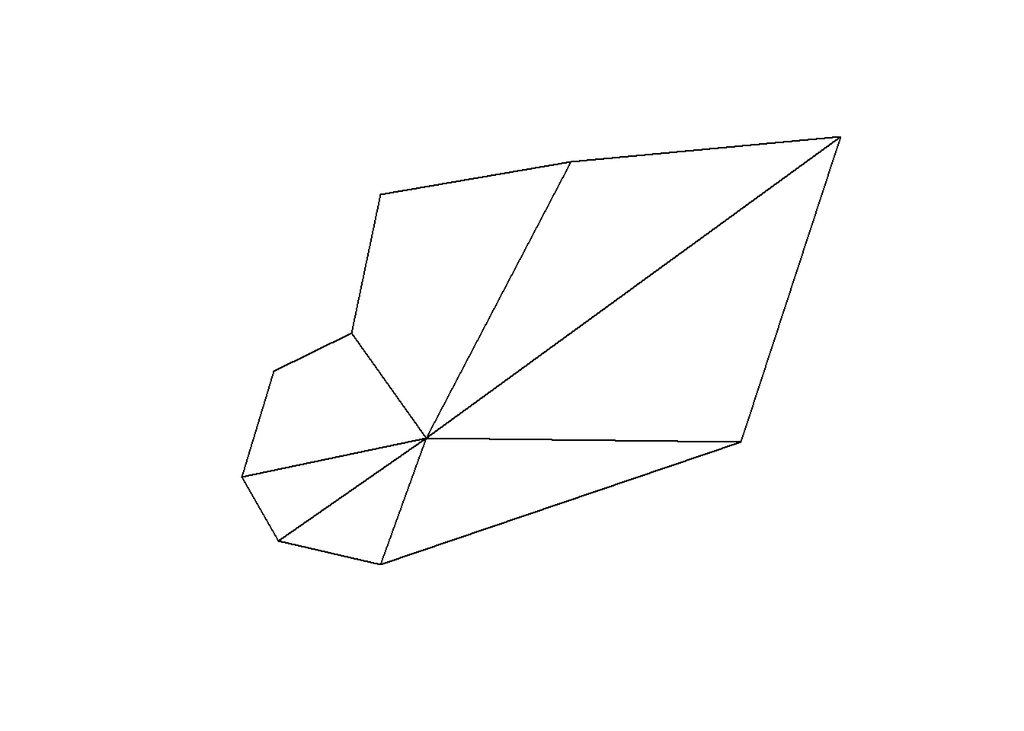

```r
plot(out3)
```

You can use the following command to plot the complete graph, including nodes and edges. These can be either the raw edges of `out2`, or the prioritized edges of `out3`, in which case they will be coloured according to their priority:

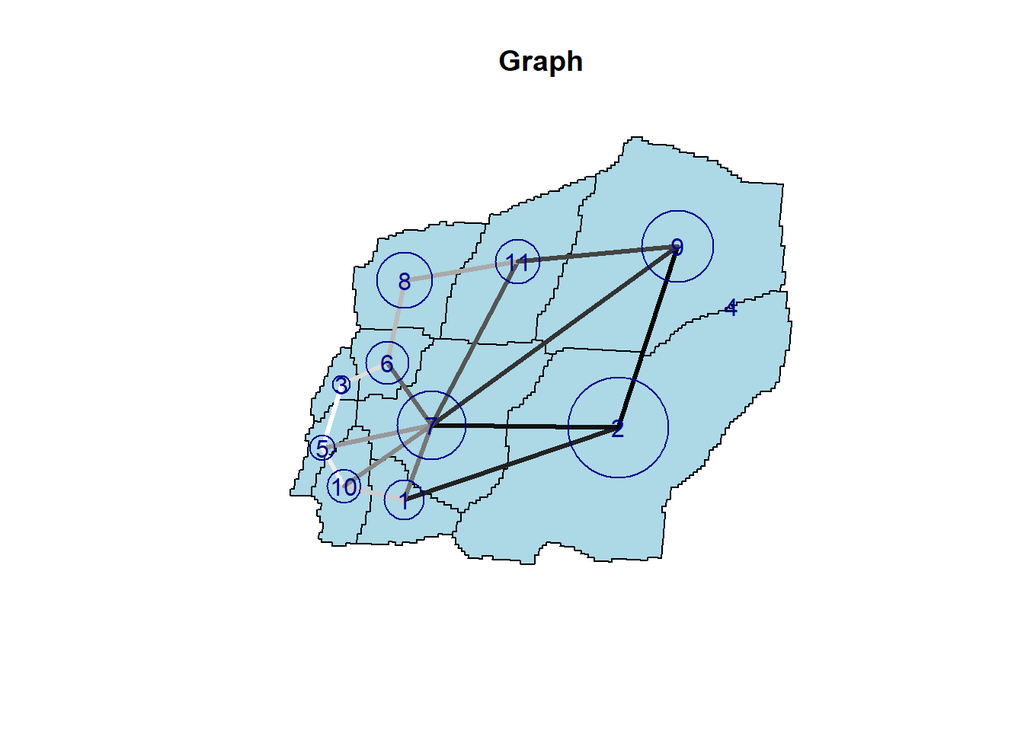

```r
plotgraph(nodes = out1, edges = out3, land_polyg = road_P)
```

You can also run the full process with one single function that does the nodes, edges, prioritization and plotting all in one go:

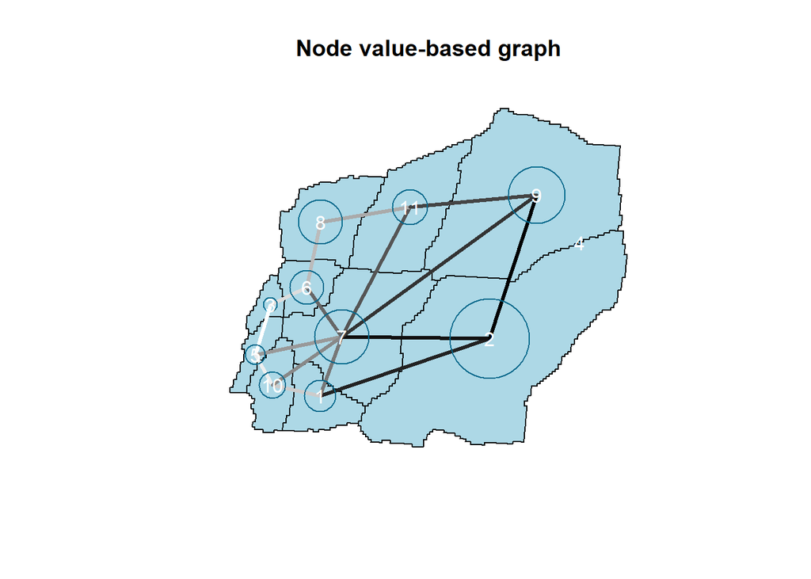

```r
out7 <- gDefrag.full(land_polyg = road_P, min_length = 10000, min_pol_area = 1000000, value_col = "forest_sum", method = "value", main = "Node value-based graph")
```

See the help files of these functions for further details and options. This tutorial was built with *RStudio* + *rmarkdown* + *knitr*. Thanks!

### REFERENCES

Mestre F., Ascensao F. & Barbosa A.M. (in review) gDefrag: A graph-based tool to help defragmenting landscapes divided by linear infrastructures.